# Student Alcohol Consumption Analysis

Shaleni Medikonda

August 17, 2019

# Introduction

The [Student Alcohol Consumption](https://www.kaggle.com/uciml/student-alcohol-consumption) dataset contains information of a secondary school math students. It gives a detailed information about their age, gender, schedule, timings, their family background and their performance or grades. The original source of information is from [UCI, Machine Learning Repository](https://archive.ics.uci.edu/ml/datasets/STUDENT+ALCOHOL+CONSUMPTION).

Alcohol Consumption is an addictive trait that could destroy careers of many. We have known this for a very long time now. Yet, the consumption of the same has always been increasing. A large new study published in *‘The Lancet’* found that, global alcohol intake has increasaed by 70%. In such a scenario, wouldn’t it be interesting to know how these alcohol consumption rates and other related factors are affecting grades of students right in the school?

Gender differences have persisted for a very long time now. Every field has some difference to show between male and female. Similarly, with respect to amount of drinking, it is a known myth that boys consume far higher levels of alcohol than girls. Well, we could call it a myth in present day scenario. Hence, let stats prove this myth right or wrong precisely!

Lets talk about parenting and other related factors, that could affect a child’s performance in the school. Adolescence is a crucial period where children could be mould in the most beautiful way possible. Giving them right environment, freedom and resources is extremely necessary for their well-being and prosperity. But are all these morals really proven? The following analysis is an effort to find out major factors that drive a student’s performance in school. This element is evaluated based on their final grade (**target variable**) received.

*Few variables crucial to the analysis are defined below:*

- sex - Sex of the student
  - Categorical variable (Female and Male)
- age - Age of the student
  - Continuous variable (in years)
- address - Address of the student
  - Categorical variable (‘Urban’ (U) or ‘Rural’ (R))
- traveltime - Time to travel from home too school
  - Continuous variable (in hours)
  - 1 - <15min, 2 - 15-30min, 3 - 30min-1hr, 4 - >1hr
- studytime - Time spent on study every week
  - Continuous Variable (in hours)
  - 1 - < 2hrs, 2 - 2-5hrs, 3 - 5-10hrs, 4 - >10hrs
- failures - number of previous class failures
  - Ordinal variable (between 0 and 4)
- romantic - Relationship status of the student
  - Categorical variable (yes or no)
- famrel - Quality of family relationship
  - Ordinal variable (from 1-very low to 5-very high)
- goout - How often does the student go out with his/her friends
  - Ordinal variable (from 1-very low to 5-very high)
- Dalc - Workday alcohol consumption
  - Ordinal variable (from 1-very low to 5-very high)
- health - Current health status
  - Ordinal variable (from 1-very low to 5-very high)
- absences - Number of school absences
  - Continuous variable (in days)
- G3 - Final Grade
  - Continuous variable (in points)

**Loading necessary packages and importing the dataset:**

```r
library('tidyverse')
library('plyr')
library('dplyr')
library('gridExtra')
library('corrgram')
library('factoextra')
library('plotly')


#importing the dataset
data <- read.csv("F:/Data Analytics-MS!/Data Mining & applications/Week 2/student-alcohol-consumption/student-mat.csv")
```

# Feature Engineering

*Finding total number of rows, columns and listing the variables in the dataset:*

```r
#Counting the number of rows
nrow(data)
```

```
## [1] 395
```

```r
#Counting number of columns
ncol(data)
```

```
## [1] 33
```

```r
#sample data output
head(data)
```

```
##   school sex age address famsize Pstatus Medu Fedu     Mjob     Fjob
## 1     GP   F  18       U     GT3       A    4    4  at_home  teacher
## 2     GP   F  17       U     GT3       T    1    1  at_home    other
## 3     GP   F  15       U     LE3       T    1    1  at_home    other
## 4     GP   F  15       U     GT3       T    4    2   health services
## 5     GP   F  16       U     GT3       T    3    3    other    other
## 6     GP   M  16       U     LE3       T    4    3 services    other
##       reason guardian traveltime studytime failures schoolsup famsup paid
## 1     course   mother          2         2        0       yes     no   no
## 2     course   father          1         2        0        no    yes   no
## 3      other   mother          1         2        3       yes     no  yes
## 4       home   mother          1         3        0        no    yes  yes
## 5       home   father          1         2        0        no    yes  yes
## 6 reputation   mother          1         2        0        no    yes  yes
##   activities nursery higher internet romantic famrel freetime goout Dalc
## 1         no     yes    yes       no       no      4        3     4    1
## 2         no      no    yes      yes       no      5        3     3    1
## 3         no     yes    yes      yes       no      4        3     2    2
## 4        yes     yes    yes      yes      yes      3        2     2    1
## 5         no     yes    yes       no       no      4        3     2    1
## 6        yes     yes    yes      yes       no      5        4     2    1
##   Walc health absences G1 G2 G3
## 1    1      3        6  5  6  6
## 2    1      3        4  5  5  6
## 3    3      3       10  7  8 10
## 4    1      5        2 15 14 15
## 5    2      5        4  6 10 10
## 6    2      5       10 15 15 15
```

```r
#variables in the dataset
str(data)
```

```
## 'data.frame':    395 obs. of  33 variables:
##  $ school    : Factor w/ 2 levels "GP","MS": 1 1 1 1 1 1 1 1 1 1 ...
##  $ sex       : Factor w/ 2 levels "F","M": 1 1 1 1 1 2 2 1 2 2 ...
##  $ age       : int  18 17 15 15 16 16 16 17 15 15 ...
##  $ address   : Factor w/ 2 levels "R","U": 2 2 2 2 2 2 2 2 2 2 ...
##  $ famsize   : Factor w/ 2 levels "GT3","LE3": 1 1 2 1 1 2 2 1 2 1 ...
##  $ Pstatus   : Factor w/ 2 levels "A","T": 1 2 2 2 2 2 2 1 1 2 ...
##  $ Medu      : int  4 1 1 4 3 4 2 4 3 3 ...
##  $ Fedu      : int  4 1 1 2 3 3 2 4 2 4 ...
##  $ Mjob      : Factor w/ 5 levels "at_home","health",..: 1 1 1 2 3 4 3 3 4 3 ...
##  $ Fjob      : Factor w/ 5 levels "at_home","health",..: 5 3 3 4 3 3 3 5 3 3 ...
##  $ reason    : Factor w/ 4 levels "course","home",..: 1 1 3 2 2 4 2 2 2 2 ...
##  $ guardian  : Factor w/ 3 levels "father","mother",..: 2 1 2 2 1 2 2 2 2 2 ...
##  $ traveltime: int  2 1 1 1 1 1 1 2 1 1 ...
##  $ studytime : int  2 2 2 3 2 2 2 2 2 2 ...
```

[output cut: 19 more lines]

```r
# Finding missing values in all the columns
data %>% is.na() %>% colSums()
```

```
##     school        sex        age    address    famsize    Pstatus
##          0          0          0          0          0          0
##       Medu       Fedu       Mjob       Fjob     reason   guardian
##          0          0          0          0          0          0
## traveltime  studytime   failures  schoolsup     famsup       paid
##          0          0          0          0          0          0
## activities    nursery     higher   internet   romantic     famrel
##          0          0          0          0          0          0
##   freetime      goout       Dalc       Walc     health   absences
##          0          0          0          0          0          0
##         G1         G2         G3
##          0          0          0
```

**We see that thet dataset contains no missing values. Also, it has 33 columns, which would be extremely lengthy to process. Since our analysis is restricted to finding factors that influence the final grade or performance of the student, we inspect variables that are important and would be interesting to interpret to narrow our research.**

School, higher education interest, schoolsup, paid, reason, father’s job, mother’s job are variables, that do not directly influence student’s performance. For an effective analysis of these, further information like particular school type, parent’s income, etc., matter, which aren’t currently available. The following sections inspect and transform the variables used in this analysis.

# Single Variable Plots

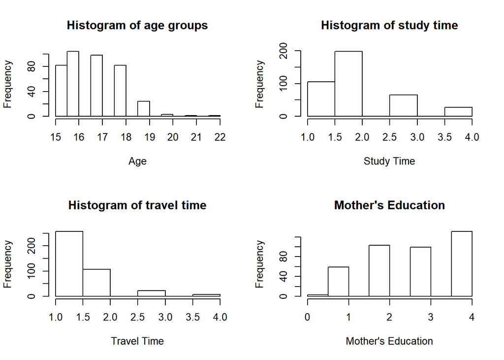

```r
layout(matrix(1:4, 2,2))

hist(data$age, main="Histogram of age groups", xlab="Age")

hist(data$traveltime, main = "Histogram of travel time", xlab = "Travel Time")


hist(data$studytime, main = "Histogram of study time", xlab = "Study Time")

hist(data$Medu, main = "Mother's Education", xlab = "Mother's Education")
```

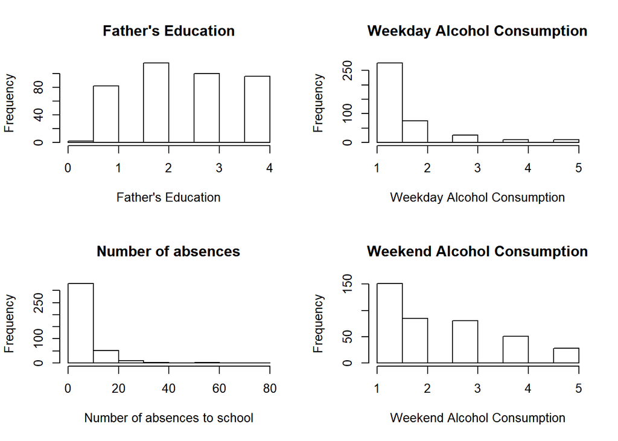

```r
layout(matrix(1:4,2,2))

hist(data$Fedu, main = "Father's Education", xlab = "Father's Education")

hist(data$absences, main = "Number of absences", xlab = "Number of absences to school")


hist( data$Dalc, main = "Weekday Alcohol Consumption", xlab = "Weekday Alcohol Consumption")

hist(data$Walc, main = "Weekend Alcohol Consumption", xlab = "Weekend Alcohol Consumption")
```

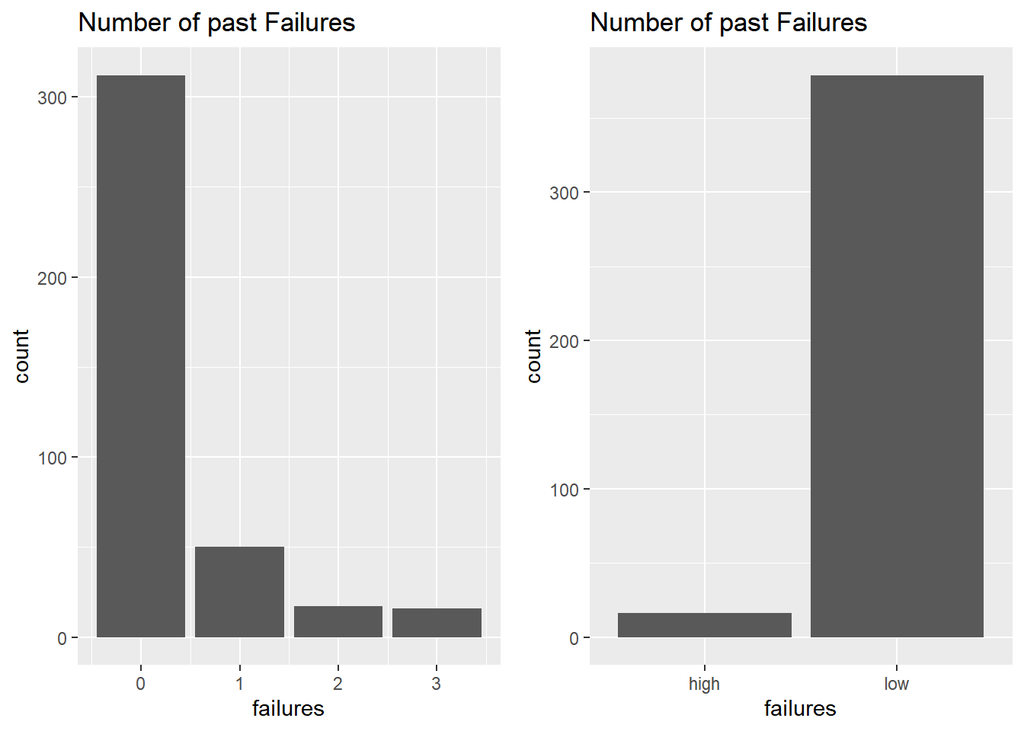

```r
p10 <- data %>% ggplot(aes(x = sex)) +  geom_bar() + ggtitle("Gender")

p11 <- data %>% ggplot(aes(x = address)) +  geom_bar()+ ggtitle("Rural and Urban ratio")

p12 <- data %>% ggplot(aes(x = failures)) +  geom_bar() + ggtitle("Number of past Failures")
#Transforming this variable with bins as high (having more than 2 failures) and low
data$failures = ifelse(data$failures>2, "high", "low")
t1 <- data %>% ggplot(aes(x = failures)) +  geom_bar() + ggtitle("Number of past Failures")
grid.arrange(p12, t1, nrow=1)
```